# California Housing Prediction

```python
import pandas as pd
from scipy import stats
import numpy as np
import matplotlib.pyplot as plt
import seaborn as sb
import statsmodels.api as sm
from pandas.api.types import is_string_dtype
from pandas.api.types import is_numeric_dtype
```

```python
pip install mlxtend
```

```
     ---------------------------------------- 1.4/1.4 MB 1.3 MB/s eta 0:00:00
```

```python
df = pd.read_csv("California Housing.csv")
```

```python
df.shape
```

```
(20640, 10)
```

```python
df.isnull().sum()
```

```
longitude               0
latitude                0
housing_median_age      0
total_rooms             0
total_bedrooms        207
population              0
households              0
median_income           0
ocean_proximity         0
median_house_value      0
dtype: int64
```

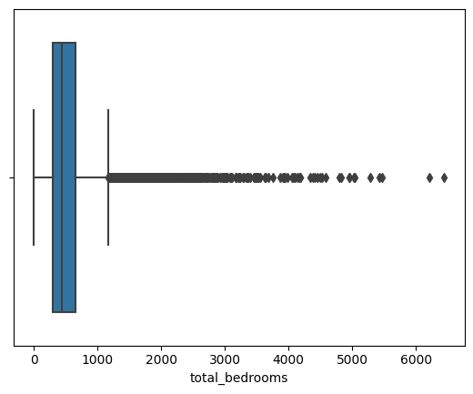

```python
sb.boxplot(x = df.total_bedrooms, data = df)
```

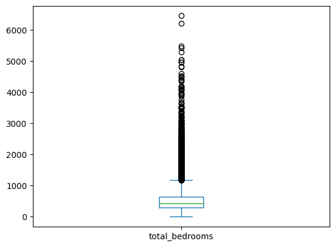

```python
df.total_bedrooms.plot.box()
```

```python
df.total_bedrooms.mode()
```

```
0    280.0
Name: total_bedrooms, dtype: float64
```

```python
df.describe()
```

|  | longitude | latitude | housing_median_age | total_rooms | total_bedrooms | population | households | median_income | median_house_value |
| --- | --- | --- | --- | --- | --- | --- | --- | --- | --- |
| count | 20640.000000 | 20640.000000 | 20640.000000 | 20640.000000 | 20433.000000 | 20640.000000 | 20640.000000 | 20640.000000 | 20640.000000 |
| mean | -119.569704 | 35.631861 | 28.639486 | 2635.763081 | 537.870553 | 1425.476744 | 499.539680 | 3.870671 | 206855.816909 |
| std | 2.003532 | 2.135952 | 12.585558 | 2181.615252 | 421.385070 | 1132.462122 | 382.329753 | 1.899822 | 115395.615874 |
| min | -124.350000 | 32.540000 | 1.000000 | 2.000000 | 1.000000 | 3.000000 | 1.000000 | 0.499900 | 14999.000000 |
| 25% | -121.800000 | 33.930000 | 18.000000 | 1447.750000 | 296.000000 | 787.000000 | 280.000000 | 2.563400 | 119600.000000 |
| 50% | -118.490000 | 34.260000 | 29.000000 | 2127.000000 | 435.000000 | 1166.000000 | 409.000000 | 3.534800 | 179700.000000 |
| 75% | -118.010000 | 37.710000 | 37.000000 | 3148.000000 | 647.000000 | 1725.000000 | 605.000000 | 4.743250 | 264725.000000 |
| max | -114.310000 | 41.950000 | 52.000000 | 39320.000000 | 6445.000000 | 35682.000000 | 6082.000000 | 15.000100 | 500001.000000 |

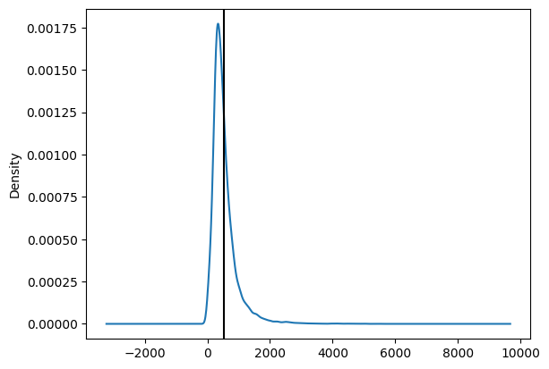

```python
df.total_bedrooms.plot.density()
plt.axvline(df.total_bedrooms.mean(), color = 'black')
```

Since the Data for total bedrooms is righty skewed most of the data is situated around the mode of the feature. Thus, we will use the mode to impute the missing values in the total_bedroom feature.

```python
df.total_bedrooms = df.total_bedrooms.fillna(df.total_bedrooms.mode()[0])

# we write [0] after mode because the mode function returns in series datatype.
```

```python
df.isnull().sum()
```

```
longitude             0
latitude              0
housing_median_age    0
total_rooms           0
total_bedrooms        0
population            0
households            0
median_income         0
ocean_proximity       0
median_house_value    0
dtype: int64
```

```python
df.describe()
```

|  | longitude | latitude | housing_median_age | total_rooms | total_bedrooms | population | households | median_income | median_house_value |
| --- | --- | --- | --- | --- | --- | --- | --- | --- | --- |
| count | 20640.000000 | 20640.000000 | 20640.000000 | 20640.000000 | 20640.000000 | 20640.000000 | 20640.000000 | 20640.000000 | 20640.000000 |
| mean | -119.569704 | 35.631861 | 28.639486 | 2635.763081 | 535.284351 | 1425.476744 | 499.539680 | 3.870671 | 206855.816909 |
| std | 2.003532 | 2.135952 | 12.585558 | 2181.615252 | 420.053240 | 1132.462122 | 382.329753 | 1.899822 | 115395.615874 |
| min | -124.350000 | 32.540000 | 1.000000 | 2.000000 | 1.000000 | 3.000000 | 1.000000 | 0.499900 | 14999.000000 |
| 25% | -121.800000 | 33.930000 | 18.000000 | 1447.750000 | 292.000000 | 787.000000 | 280.000000 | 2.563400 | 119600.000000 |
| 50% | -118.490000 | 34.260000 | 29.000000 | 2127.000000 | 431.000000 | 1166.000000 | 409.000000 | 3.534800 | 179700.000000 |
| 75% | -118.010000 | 37.710000 | 37.000000 | 3148.000000 | 643.250000 | 1725.000000 | 605.000000 | 4.743250 | 264725.000000 |
| max | -114.310000 | 41.950000 | 52.000000 | 39320.000000 | 6445.000000 | 35682.000000 | 6082.000000 | 15.000100 | 500001.000000 |

```python
cols = ['housing_median_age', 'total_rooms',
       'total_bedrooms', 'population', 'households', 'median_income', 'median_house_value']
cols
```

```
['housing_median_age',
 'total_rooms',
 'total_bedrooms',
 'population',
 'households',
 'median_income',
 'median_house_value']
```

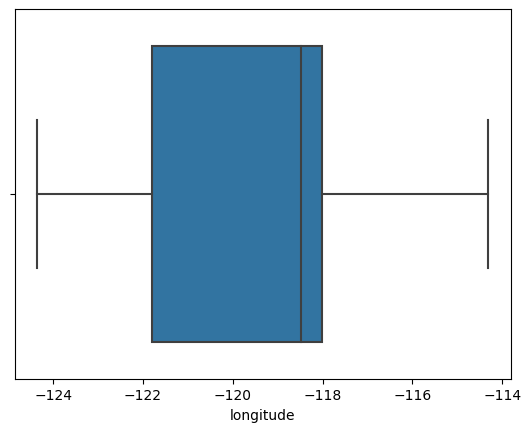

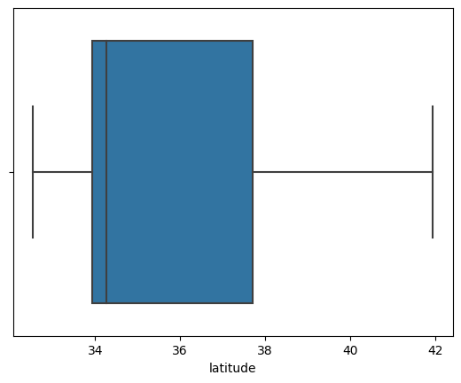

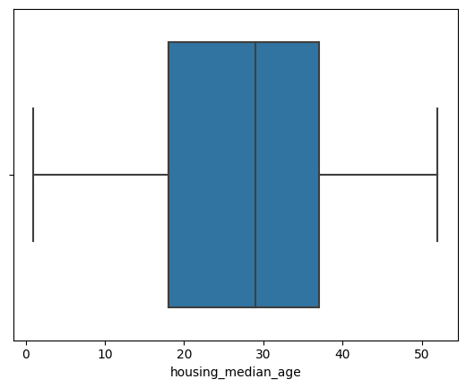

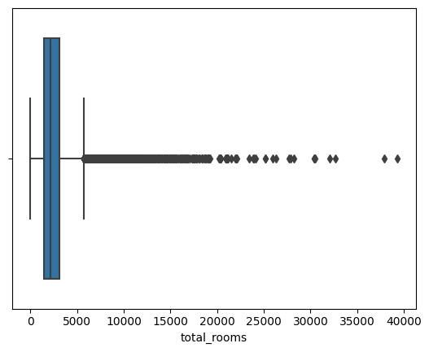

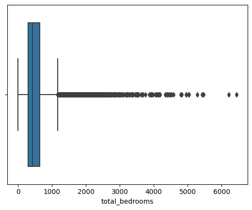

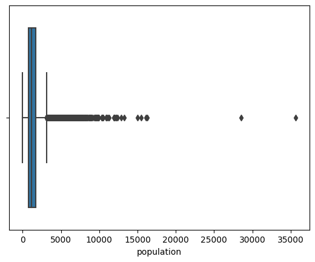

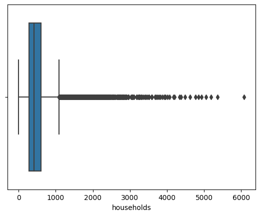

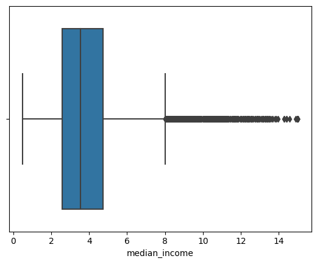

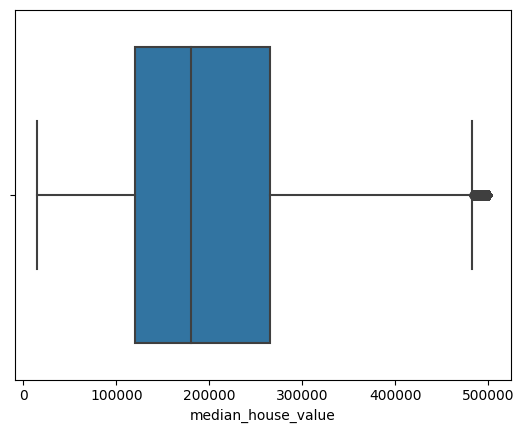

```python
for i in df.select_dtypes(include = 'number'):
    sb.boxplot(x = df[i])
    plt.show()
```

From the above box plots we can see that none of the features have outliers on the lower end. House Median Age has no outliers.

```python
c = 0
for j in df.select_dtypes(include = 'number'):
    u = (df[j] > (df[j].quantile(0.75) + 1.5 * (df[j].quantile(0.75) - df[j].quantile(0.25)))).sum()
    l = (df[j] < (df[j].quantile(0.25) - 1.5 * (df[j].quantile(0.75) - df[j].quantile(0.25)))).sum()
    print(j,u+l)
    c = 0
```

```
longitude 0
latitude 0
housing_median_age 0
total_rooms 1287
total_bedrooms 1279
population 1196
households 1220
median_income 681
median_house_value 1071
```

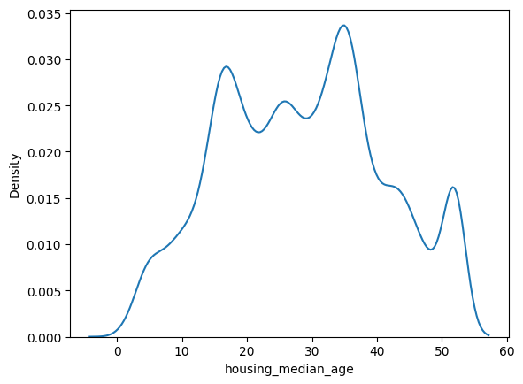

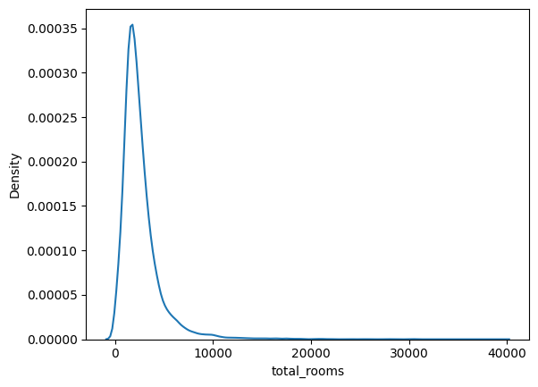

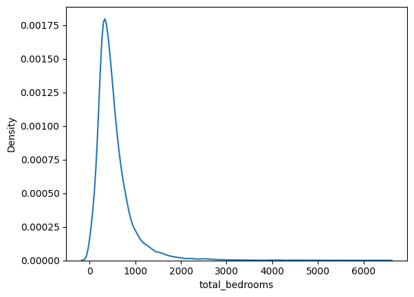

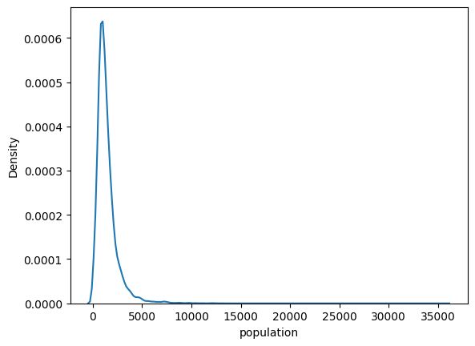

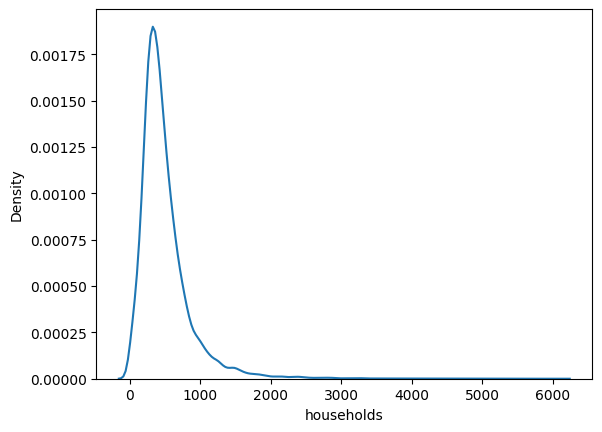

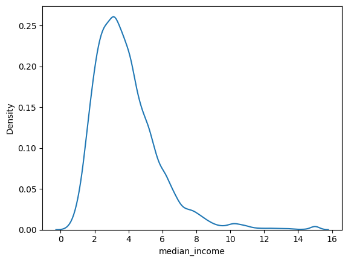

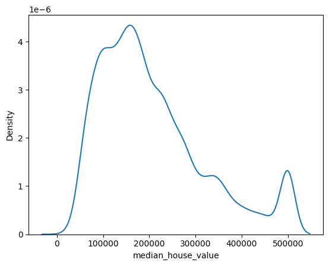

```python
# density plots to check for normal
for i in cols:
    sb.kdeplot(x = df[i])
    plt.show()
```

features - total_rooms, total_bedrooms, population, households, median income are rightly skewed. The target value median_house_value has a bimodel distribution

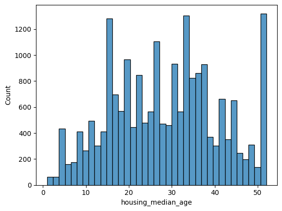

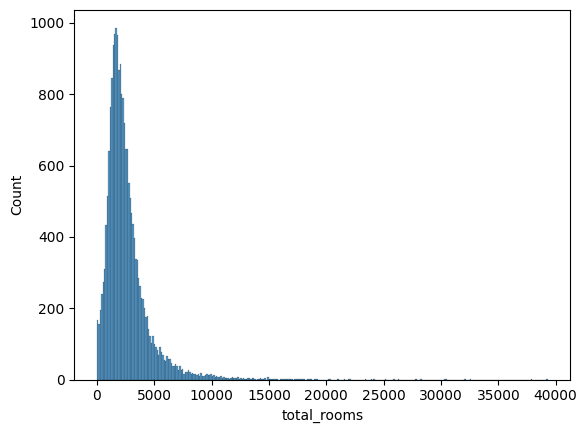

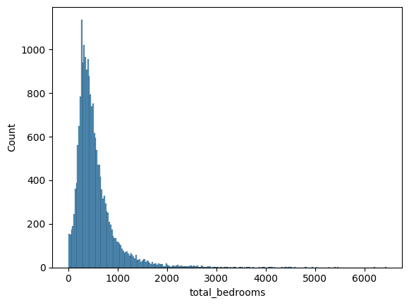

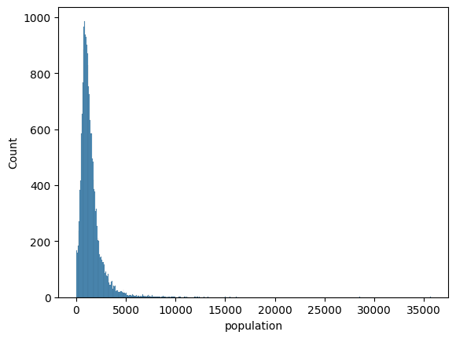

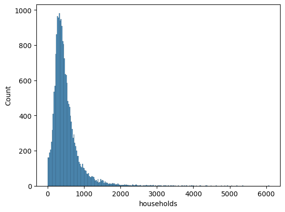

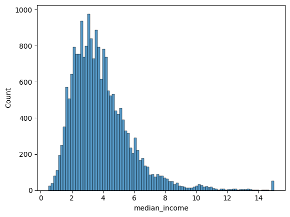

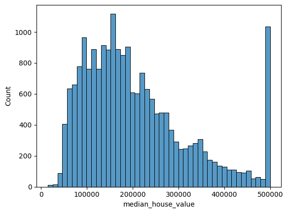

```python
for i in cols:
    sb.histplot(x = df[i])
    plt.show()
```

```python
df1 = pd.DataFrame([df.housing_median_age, df.total_rooms,df.total_bedrooms, df.population, df.households, df.median_income, df.median_house_value]).T
df1
```

|  | housing_median_age | total_rooms | total_bedrooms | population | households | median_income | median_house_value |
| --- | --- | --- | --- | --- | --- | --- | --- |
| 0 | 41.0 | 880.0 | 129.0 | 322.0 | 126.0 | 8.3252 | 452600.0 |
| 1 | 21.0 | 7099.0 | 1106.0 | 2401.0 | 1138.0 | 8.3014 | 358500.0 |
| 2 | 52.0 | 1467.0 | 190.0 | 496.0 | 177.0 | 7.2574 | 352100.0 |
| 3 | 52.0 | 1274.0 | 235.0 | 558.0 | 219.0 | 5.6431 | 341300.0 |
| 4 | 52.0 | 1627.0 | 280.0 | 565.0 | 259.0 | 3.8462 | 342200.0 |
| ... | ... | ... | ... | ... | ... | ... | ... |
| 20635 | 25.0 | 1665.0 | 374.0 | 845.0 | 330.0 | 1.5603 | 78100.0 |
| 20636 | 18.0 | 697.0 | 150.0 | 356.0 | 114.0 | 2.5568 | 77100.0 |
| 20637 | 17.0 | 2254.0 | 485.0 | 1007.0 | 433.0 | 1.7000 | 92300.0 |
| 20638 | 18.0 | 1860.0 | 409.0 | 741.0 | 349.0 | 1.8672 | 84700.0 |
| 20639 | 16.0 | 2785.0 | 616.0 | 1387.0 | 530.0 | 2.3886 | 89400.0 |

20640 rows × 7 columns

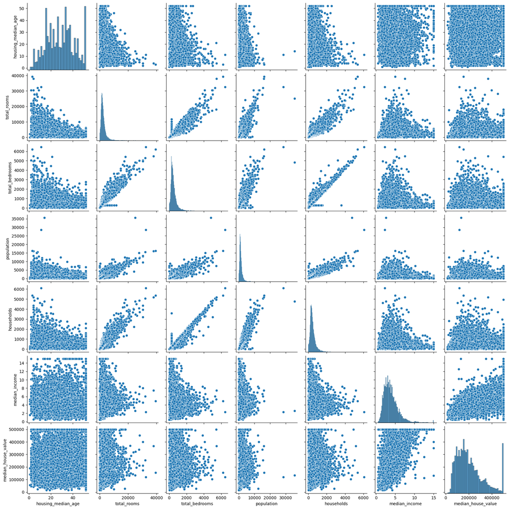

```python
# using pairplots to check correlation  between the features
sb.pairplot(df1)
```

```python
pd.DataFrame([df.housing_median_age,df.total_rooms]).T
```

|  | housing_median_age | total_rooms |
| --- | --- | --- |
| 0 | 41 | 880 |
| 1 | 21 | 7099 |
| 2 | 52 | 1467 |
| 3 | 52 | 1274 |
| 4 | 52 | 1627 |
| ... | ... | ... |
| 20635 | 25 | 1665 |
| 20636 | 18 | 697 |
| 20637 | 17 | 2254 |
| 20638 | 18 | 1860 |
| 20639 | 16 | 2785 |

20640 rows × 2 columns

We can see that there is a positive correlation between, total rooms and total bedrooms, total rooms and population, total rooms and household, total bedroom and population, total bedroom and household, population and household.

The intution behind these relationship is very logical.As the number of bedrooms increase in a district the number of rooms increase. As the households increase requirement of bedrooms increase and thus total bedrooms increase.

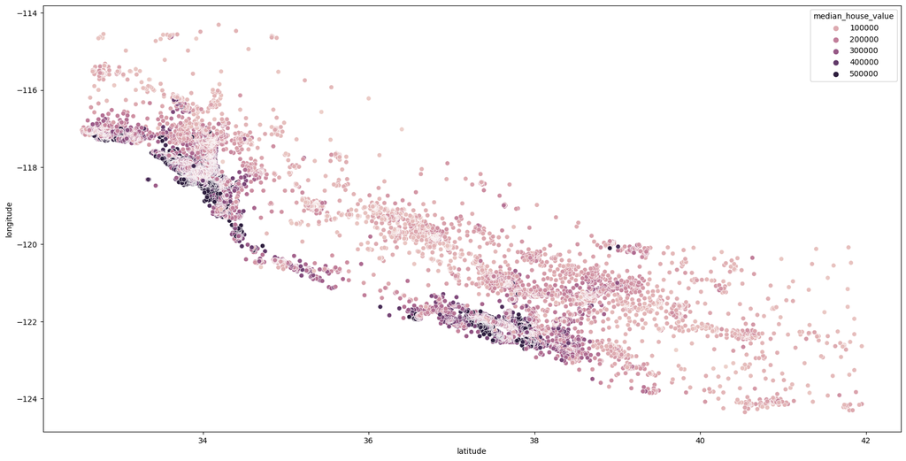

```python
plt.figure(figsize = (20,10))
sb.scatterplot(x = df.latitude, y = df.longitude, hue = df.median_house_value)
```

Comparing the above graph to the map of California we can see the houses situated on the sea side near ocean have a higher value

Feautre Engineering

```python
df.ocean_proximity.value_counts()
```

```
ocean_proximity
<1H OCEAN     9136
INLAND        6551
NEAR OCEAN    2658
NEAR BAY      2290
ISLAND           5
Name: count, dtype: int64
```

```python
df.drop(df[df.ocean_proximity == "ISLAND"].index, inplace = True)
df.shape
```

```
(20635, 10)
```

```python
df.ocean_proximity.value_counts()
```

```
ocean_proximity
<1H OCEAN     9136
INLAND        6551
NEAR OCEAN    2658
NEAR BAY      2290
Name: count, dtype: int64
```

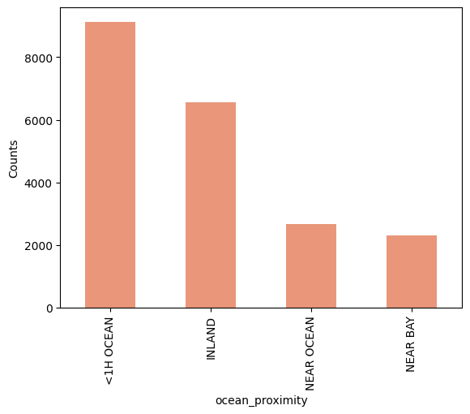

```python
df['ocean_proximity'].value_counts().plot.bar(color = 'darksalmon', width = 0.5)
plt.ylabel("Counts")
```

```python
dummies_df = pd.get_dummies(df.ocean_proximity, drop_first = True , dtype = int)
df2 = pd.concat([df, dummies_df], axis = 1)
df2
```

|  | longitude | latitude | housing_median_age | total_rooms | total_bedrooms | population | households | median_income | ocean_proximity | median_house_value | INLAND | NEAR BAY | NEAR OCEAN |
| --- | --- | --- | --- | --- | --- | --- | --- | --- | --- | --- | --- | --- | --- |
| 0 | -122.23 | 37.88 | 41 | 880 | 129.0 | 322 | 126 | 8.3252 | NEAR BAY | 452600 | 0 | 1 | 0 |
| 1 | -122.22 | 37.86 | 21 | 7099 | 1106.0 | 2401 | 1138 | 8.3014 | NEAR BAY | 358500 | 0 | 1 | 0 |
| 2 | -122.24 | 37.85 | 52 | 1467 | 190.0 | 496 | 177 | 7.2574 | NEAR BAY | 352100 | 0 | 1 | 0 |
| 3 | -122.25 | 37.85 | 52 | 1274 | 235.0 | 558 | 219 | 5.6431 | NEAR BAY | 341300 | 0 | 1 | 0 |
| 4 | -122.25 | 37.85 | 52 | 1627 | 280.0 | 565 | 259 | 3.8462 | NEAR BAY | 342200 | 0 | 1 | 0 |
| ... | ... | ... | ... | ... | ... | ... | ... | ... | ... | ... | ... | ... | ... |
| 20635 | -121.09 | 39.48 | 25 | 1665 | 374.0 | 845 | 330 | 1.5603 | INLAND | 78100 | 1 | 0 | 0 |
| 20636 | -121.21 | 39.49 | 18 | 697 | 150.0 | 356 | 114 | 2.5568 | INLAND | 77100 | 1 | 0 | 0 |
| 20637 | -121.22 | 39.43 | 17 | 2254 | 485.0 | 1007 | 433 | 1.7000 | INLAND | 92300 | 1 | 0 | 0 |
| 20638 | -121.32 | 39.43 | 18 | 1860 | 409.0 | 741 | 349 | 1.8672 | INLAND | 84700 | 1 | 0 | 0 |
| 20639 | -121.24 | 39.37 | 16 | 2785 | 616.0 | 1387 | 530 | 2.3886 | INLAND | 89400 | 1 | 0 | 0 |

20635 rows × 13 columns

```python
num_df = df2.select_dtypes(include = "number")
num_df.drop(["longitude", "latitude"], axis = 1)
num_df
```

|  | longitude | latitude | housing_median_age | total_rooms | total_bedrooms | population | households | median_income | median_house_value | INLAND | NEAR BAY | NEAR OCEAN |
| --- | --- | --- | --- | --- | --- | --- | --- | --- | --- | --- | --- | --- |
| 0 | -122.23 | 37.88 | 41 | 880 | 129.0 | 322 | 126 | 8.3252 | 452600 | 0 | 1 | 0 |
| 1 | -122.22 | 37.86 | 21 | 7099 | 1106.0 | 2401 | 1138 | 8.3014 | 358500 | 0 | 1 | 0 |
| 2 | -122.24 | 37.85 | 52 | 1467 | 190.0 | 496 | 177 | 7.2574 | 352100 | 0 | 1 | 0 |
| 3 | -122.25 | 37.85 | 52 | 1274 | 235.0 | 558 | 219 | 5.6431 | 341300 | 0 | 1 | 0 |
| 4 | -122.25 | 37.85 | 52 | 1627 | 280.0 | 565 | 259 | 3.8462 | 342200 | 0 | 1 | 0 |
| ... | ... | ... | ... | ... | ... | ... | ... | ... | ... | ... | ... | ... |
| 20635 | -121.09 | 39.48 | 25 | 1665 | 374.0 | 845 | 330 | 1.5603 | 78100 | 1 | 0 | 0 |
| 20636 | -121.21 | 39.49 | 18 | 697 | 150.0 | 356 | 114 | 2.5568 | 77100 | 1 | 0 | 0 |
| 20637 | -121.22 | 39.43 | 17 | 2254 | 485.0 | 1007 | 433 | 1.7000 | 92300 | 1 | 0 | 0 |
| 20638 | -121.32 | 39.43 | 18 | 1860 | 409.0 | 741 | 349 | 1.8672 | 84700 | 1 | 0 | 0 |
| 20639 | -121.24 | 39.37 | 16 | 2785 | 616.0 | 1387 | 530 | 2.3886 | 89400 | 1 | 0 | 0 |

20635 rows × 12 columns

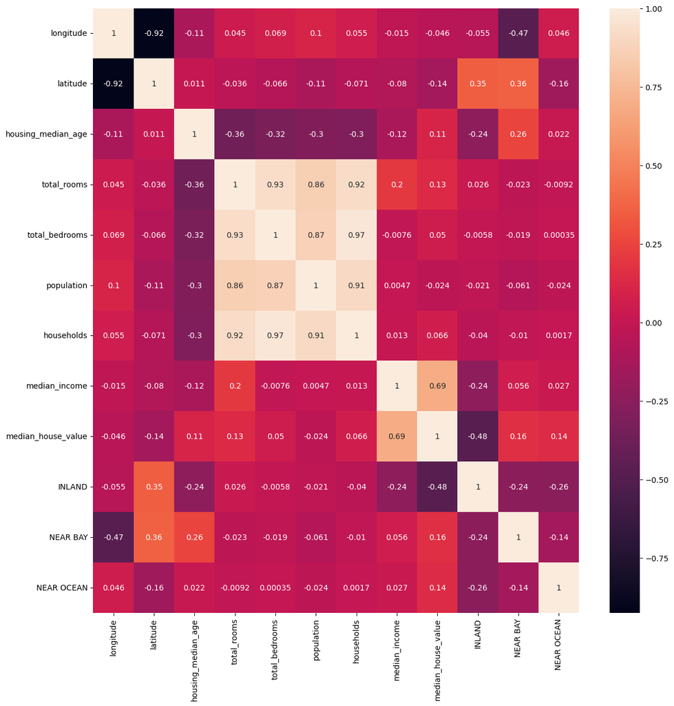

```python
plt.figure(figsize = (14,14))
sb.heatmap(num_df.corr(), annot = True)
```

# FEATURE ENGINEERING

```python
# adding Bedroom Ratio in the table
df2.bedroom_ratio = df2.total_bedrooms/df2.total_rooms
```

```python
df2
```

|  | longitude | latitude | housing_median_age | total_rooms | total_bedrooms | population | households | median_income | ocean_proximity | median_house_value | INLAND | NEAR BAY | NEAR OCEAN |
| --- | --- | --- | --- | --- | --- | --- | --- | --- | --- | --- | --- | --- | --- |
| 0 | -122.23 | 37.88 | 41 | 880 | 129.0 | 322 | 126 | 8.3252 | NEAR BAY | 452600 | 0 | 1 | 0 |
| 1 | -122.22 | 37.86 | 21 | 7099 | 1106.0 | 2401 | 1138 | 8.3014 | NEAR BAY | 358500 | 0 | 1 | 0 |
| 2 | -122.24 | 37.85 | 52 | 1467 | 190.0 | 496 | 177 | 7.2574 | NEAR BAY | 352100 | 0 | 1 | 0 |
| 3 | -122.25 | 37.85 | 52 | 1274 | 235.0 | 558 | 219 | 5.6431 | NEAR BAY | 341300 | 0 | 1 | 0 |
| 4 | -122.25 | 37.85 | 52 | 1627 | 280.0 | 565 | 259 | 3.8462 | NEAR BAY | 342200 | 0 | 1 | 0 |
| ... | ... | ... | ... | ... | ... | ... | ... | ... | ... | ... | ... | ... | ... |
| 20635 | -121.09 | 39.48 | 25 | 1665 | 374.0 | 845 | 330 | 1.5603 | INLAND | 78100 | 1 | 0 | 0 |
| 20636 | -121.21 | 39.49 | 18 | 697 | 150.0 | 356 | 114 | 2.5568 | INLAND | 77100 | 1 | 0 | 0 |
| 20637 | -121.22 | 39.43 | 17 | 2254 | 485.0 | 1007 | 433 | 1.7000 | INLAND | 92300 | 1 | 0 | 0 |
| 20638 | -121.32 | 39.43 | 18 | 1860 | 409.0 | 741 | 349 | 1.8672 | INLAND | 84700 | 1 | 0 | 0 |
| 20639 | -121.24 | 39.37 | 16 | 2785 | 616.0 | 1387 | 530 | 2.3886 | INLAND | 89400 | 1 | 0 | 0 |

20635 rows × 13 columns

```python
df2['bedroom_ratio'] = (df2['total_bedrooms']/df2['total_rooms'])
df2['rooms_per_household'] = (df2['total_rooms']/df2['households'])
df2
```

|  | longitude | latitude | housing_median_age | total_rooms | total_bedrooms | population | households | median_income | ocean_proximity | median_house_value | INLAND | NEAR BAY | NEAR OCEAN | bedroom_ratio | rooms_per_household |
| --- | --- | --- | --- | --- | --- | --- | --- | --- | --- | --- | --- | --- | --- | --- | --- |
| 0 | -122.23 | 37.88 | 41 | 880 | 129.0 | 322 | 126 | 8.3252 | NEAR BAY | 452600 | 0 | 1 | 0 | 0.146591 | 6.984127 |
| 1 | -122.22 | 37.86 | 21 | 7099 | 1106.0 | 2401 | 1138 | 8.3014 | NEAR BAY | 358500 | 0 | 1 | 0 | 0.155797 | 6.238137 |
| 2 | -122.24 | 37.85 | 52 | 1467 | 190.0 | 496 | 177 | 7.2574 | NEAR BAY | 352100 | 0 | 1 | 0 | 0.129516 | 8.288136 |
| 3 | -122.25 | 37.85 | 52 | 1274 | 235.0 | 558 | 219 | 5.6431 | NEAR BAY | 341300 | 0 | 1 | 0 | 0.184458 | 5.817352 |
| 4 | -122.25 | 37.85 | 52 | 1627 | 280.0 | 565 | 259 | 3.8462 | NEAR BAY | 342200 | 0 | 1 | 0 | 0.172096 | 6.281853 |
| ... | ... | ... | ... | ... | ... | ... | ... | ... | ... | ... | ... | ... | ... | ... | ... |
| 20635 | -121.09 | 39.48 | 25 | 1665 | 374.0 | 845 | 330 | 1.5603 | INLAND | 78100 | 1 | 0 | 0 | 0.224625 | 5.045455 |
| 20636 | -121.21 | 39.49 | 18 | 697 | 150.0 | 356 | 114 | 2.5568 | INLAND | 77100 | 1 | 0 | 0 | 0.215208 | 6.114035 |
| 20637 | -121.22 | 39.43 | 17 | 2254 | 485.0 | 1007 | 433 | 1.7000 | INLAND | 92300 | 1 | 0 | 0 | 0.215173 | 5.205543 |
| 20638 | -121.32 | 39.43 | 18 | 1860 | 409.0 | 741 | 349 | 1.8672 | INLAND | 84700 | 1 | 0 | 0 | 0.219892 | 5.329513 |
| 20639 | -121.24 | 39.37 | 16 | 2785 | 616.0 | 1387 | 530 | 2.3886 | INLAND | 89400 | 1 | 0 | 0 | 0.221185 | 5.254717 |

20635 rows × 15 columns

```python
num_df = df2.select_dtypes(include = "number")
num_df = num_df.drop(['longitude', 'latitude'], axis =1)
num_df
```

|  | housing_median_age | total_rooms | total_bedrooms | population | households | median_income | median_house_value | INLAND | NEAR BAY | NEAR OCEAN | bedroom_ratio | rooms_per_household |
| --- | --- | --- | --- | --- | --- | --- | --- | --- | --- | --- | --- | --- |
| 0 | 41 | 880 | 129.0 | 322 | 126 | 8.3252 | 452600 | 0 | 1 | 0 | 0.146591 | 6.984127 |
| 1 | 21 | 7099 | 1106.0 | 2401 | 1138 | 8.3014 | 358500 | 0 | 1 | 0 | 0.155797 | 6.238137 |
| 2 | 52 | 1467 | 190.0 | 496 | 177 | 7.2574 | 352100 | 0 | 1 | 0 | 0.129516 | 8.288136 |
| 3 | 52 | 1274 | 235.0 | 558 | 219 | 5.6431 | 341300 | 0 | 1 | 0 | 0.184458 | 5.817352 |
| 4 | 52 | 1627 | 280.0 | 565 | 259 | 3.8462 | 342200 | 0 | 1 | 0 | 0.172096 | 6.281853 |
| ... | ... | ... | ... | ... | ... | ... | ... | ... | ... | ... | ... | ... |
| 20635 | 25 | 1665 | 374.0 | 845 | 330 | 1.5603 | 78100 | 1 | 0 | 0 | 0.224625 | 5.045455 |
| 20636 | 18 | 697 | 150.0 | 356 | 114 | 2.5568 | 77100 | 1 | 0 | 0 | 0.215208 | 6.114035 |
| 20637 | 17 | 2254 | 485.0 | 1007 | 433 | 1.7000 | 92300 | 1 | 0 | 0 | 0.215173 | 5.205543 |
| 20638 | 18 | 1860 | 409.0 | 741 | 349 | 1.8672 | 84700 | 1 | 0 | 0 | 0.219892 | 5.329513 |
| 20639 | 16 | 2785 | 616.0 | 1387 | 530 | 2.3886 | 89400 | 1 | 0 | 0 | 0.221185 | 5.254717 |

20635 rows × 12 columns

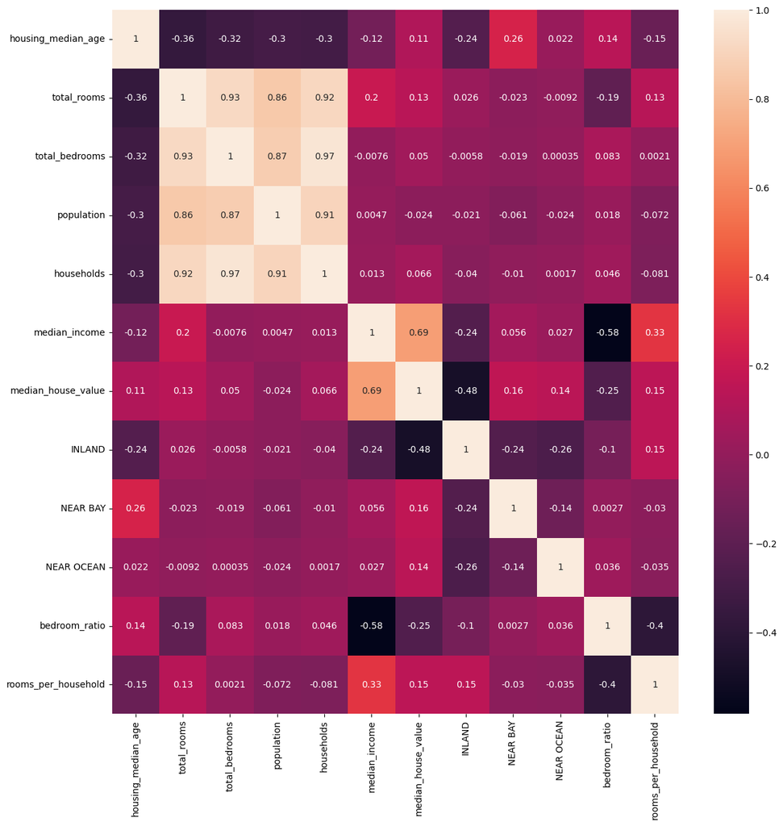

```python
plt.figure(figsize = (14,14))
sb.heatmap(num_df.corr(), annot = True)
```

```python
df_y = num_df['median_house_value']
df_x = num_df[['housing_median_age', 'total_rooms', 'total_bedrooms', 'population',
       'households', 'median_income', 'INLAND',
       'NEAR BAY', 'NEAR OCEAN', 'bedroom_ratio', 'rooms_per_household']]
```

```python
df_x
df_y
```

```
0        452600
1        358500
2        352100
3        341300
4        342200
          ...
20635     78100
20636     77100
20637     92300
20638     84700
20639     89400
Name: median_house_value, Length: 20635, dtype: int64
```

```python
#feature selection using exhaustive feature selection

from sklearn.linear_model import LinearRegression
from mlxtend.feature_selection import ExhaustiveFeatureSelector

# Define the estimator (model)
model = LinearRegression()

# Define the feature selector
efs = ExhaustiveFeatureSelector(model, min_features=4, max_features=6, scoring='r2')

# Perform feature selection
efs.fit(df_x, df_y)

# Get the selected feature subsets
best_features = efs.best_feature_names_

# Print the results
print('Best features:', best_features)
print('Best score:', efs.best_score_)
```

[output not shown]